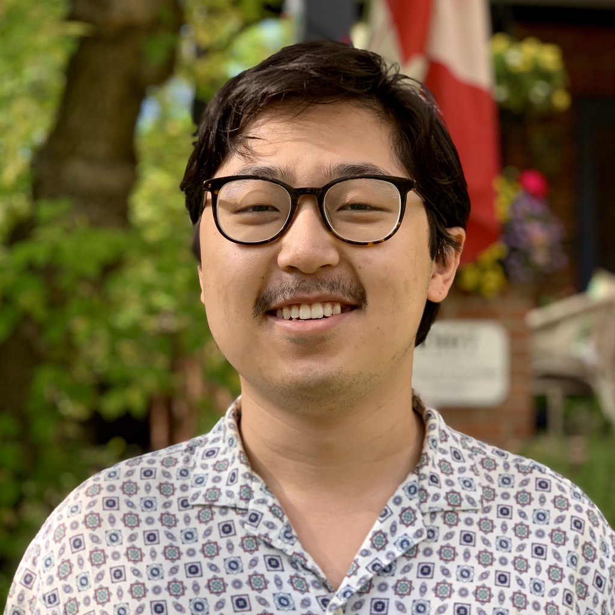

# Andrew Zhao

## Hello!

I’m a young researcher currently working at [Pollara Strategic Insights](https://www.pollara.com/). I am interested in immigration, race, and political participation. My senior thesis focused on how immigrants integrate politically upon moving to the United States.

Outside of work, I love playing rec ball hockey, preserving my grandpa’s Chinese recipes, and running [SUNIA](https://www.sunia.ca/), an educational summer camp for high school students.

I am grateful to live and work in Amiskwaciwâskahikan (Edmonton) with my dog, Hector. My pronouns are he/him.

## Education

**University of Toronto**

B.A. (Hons.) Political Science and Philosophy | 2016–2020

Thesis: *Do Immigrants from Democracies Incorporate Better? The Effect of Democratic Origins on Immigrant Political Incorporation* (supervised by Kenichi Ariga)

## Employment

**Pollara Strategic Insights** | Research Manager and Director, Advanced Analytics | Mar 2021–

**Forum Research** | Research Analyst | Oct 2019–Feb 2021

**University of Toronto** | Research Assistant to Professor Neil Nevitte | Jan 2019–Jul 2020

## Community Work

**SUNIA**

- Executive Director | Aug 2020–
- Camp Counsellor | Dec 2015–

**Harold Innis Foundation**

- Director | Dec 2020–

## Selected Awards

**Suzanne and Edwin Goodman Prize** | Received as the graduate in the Political Science Specialist program.

**Wasser Leadership Scholarship** | For “sustained leadership contributions” over 4 years to Innis College.

**University of Toronto Student Leadership Award** | For “exemplary contributions and significant impact on U of T.”

**Paul L. Nathanson Scholarship**

**Stephen Clarkson Scholarship in Political Economy**

**Andrew Nigrini Sr. Memorial Scholarship in Political Science**

**Jackman Scholar Award**

## Skills

R, SQLite, Tableau, SPSS (reluctantly), GIMP, Final Cut Pro